# Inspect training results for Convpoint

```python
import numpy as np
import pandas as pd
from itertools import cycle, islice
import matplotlib.pyplot as plt
```

### Houssem Benhmid

```python
d2 = pd.read_csv (r'/data/semantic3d_data/convpoint/examples/semantic3d/interpolated/rescaled_8058_8059_106261_106281.labels', delimiter=' ', header= None)
```

```python
d2
```

[output not shown]

123737096 rows × 1 columns

```python
d2[0].unique()
```

```
array([ 4,  2,  1, 11, 10,  3,  5, 12,  7,  6,  8,  9])
```

```python
d = pd.read_csv (r'/data/semantic3d_data/convpoint/examples/semantic3d/data/TEST/rescaled_8054_8055_106267_106281.txt', delimiter=' ', header= None)
```

```python
d1
```

[output not shown]

75507515 rows × 3 columns

```python
d1 = d.drop([3, 4,5,6], axis=1)
```

```python
d2[0]
```

[output not shown]

```python
def _label_to_colors(labels):
    map_label_to_color = {
        0: [255, 255, 255],  # white unclassified
        1: [153, 255, 153],  # light green natural ground
        2: [0, 204, 0],  # green low vegetation
        3: [0, 102, 0],  # dark green high vegetation
        4: [102, 0, 0],  # dark red buildings
        5: [0, 76, 153],  # blue road
        6: [6, 96, 96],  # grey wire structure
        7: [255, 69, 0],  # orangered vehicules
        8: [160, 82, 45],  #Sienna lamps
        9: [128, 0, 0],  # maron street signs
        10: [102, 255, 255],  #  light blue manmade terrain
        11: [255, 215, 0],  # gold barrier
        12: [128, 128, 0],  # remaining hard scapes
    }
    a = np.array([map_label_to_color[label] for label in labels]).astype(np.int32)
    return pd.DataFrame(a,columns=['R', 'G', 'B'])
```

```python
d4 = _label_to_colors(d2[0])
```

```python
d4
```

|  | R | G | B |
| --- | --- | --- | --- |
| 0 | 102 | 0 | 0 |
| 1 | 102 | 0 | 0 |
| 2 | 102 | 0 | 0 |
| 3 | 102 | 0 | 0 |
| 4 | 102 | 0 | 0 |
| ... | ... | ... | ... |
| 75507510 | 102 | 0 | 0 |
| 75507511 | 102 | 0 | 0 |
| 75507512 | 102 | 0 | 0 |
| 75507513 | 102 | 0 | 0 |
| 75507514 | 102 | 0 | 0 |

75507515 rows × 3 columns

```python
result = pd.concat([d1, d4], axis=1)
```

```python
result
```

|  | 0 | 1 | 2 | R | G | B |
| --- | --- | --- | --- | --- | --- | --- |
| 0 | 744.898 | -424.247 | 214.313 | 102 | 0 | 0 |
| 1 | 744.789 | -424.199 | 214.423 | 102 | 0 | 0 |
| 2 | 745.811 | -422.539 | 216.554 | 102 | 0 | 0 |
| 3 | 745.871 | -422.414 | 216.406 | 102 | 0 | 0 |
| 4 | 745.859 | -422.306 | 216.243 | 102 | 0 | 0 |
| ... | ... | ... | ... | ... | ... | ... |
| 75507510 | 798.217 | -93.090 | 223.755 | 102 | 0 | 0 |
| 75507511 | 798.125 | -93.180 | 223.787 | 102 | 0 | 0 |
| 75507512 | 798.218 | -93.071 | 223.800 | 102 | 0 | 0 |
| 75507513 | 798.152 | -93.160 | 223.839 | 102 | 0 | 0 |
| 75507514 | 798.176 | -93.137 | 223.881 | 102 | 0 | 0 |

75507515 rows × 6 columns

```python
result.to_csv(r'/data/semantic3d_data/convpoint/examples/semantic3d/check/rescaled_8054_8055_106267_106281_check1fusion.txt', index = False,header = None,sep=' ')
```

```python
def stats_iou_per_class(cm, ignore_missing_classes=True):
    """Compute the iou per class and average iou
        Puts -1 for invalid values
        returns average iou, iou per class
    """

    sums = (np.sum(cm, axis=1) + np.sum(cm, axis=0) - np.diag(cm))
    mask  = (sums>0)
    sums[sums==0] = 1
    iou_per_class = np.diag(cm) / sums
    iou_per_class[np.logical_not(mask)] = -1

    if mask.sum()>0:
        average_iou = iou_per_class[mask].mean()
    else:
        average_iou = 0

    return average_iou, iou_per_class
```

```python
A = [[1, 4, 5, 12], [5, 8, 9, 0], [6, 7, 11, 19],[3, 7, 2, 1]]
```

```python
l = stats_iou_per_class(A)[1]
```

```python
l
```

```
array([0.02777778, 0.2       , 0.18644068, 0.02272727])
```

```python
#iou = np.array(cls_IoU_list).flatten()
df = pd.DataFrame(list(zip(l)),  columns =['iou'])
df.to_csv(r'/data/semantic3d_data/shellnet/result_analysis/trainingresultstt.txt', index = False,header = True,sep=' ', float_format='%.3f')
```

```python
l1 =[]
```

```python
 l1.append(l)
```

```python
l1
```

```
[array([0.02777778, 0.2       , 0.18644068, 0.02272727]),
 array([0.02777778, 0.2       , 0.18644068, 0.02272727])]
```

```python
rec = np.array(l1).flatten()
```

```python
rec
```

```
array([0.02777778, 0.2       , 0.18644068, 0.02272727, 0.02777778,
       0.2       , 0.18644068, 0.02272727])
```

## check ious per class on 28/07

```python
d = pd.read_csv (r'/data/semantic3d_data/convpoint/examples/semantic3d/models/sem8_8192_fusion_2021-07-29-15-40-38/trainingresults.txt', delimiter=' ', header=0)
```

```python
d
```

|  | iou | precision | f1score |
| --- | --- | --- | --- |
| 0 | 0.376 | 0.553 | 0.546 |
| 1 | 0.277 | 0.446 | 0.434 |
| 2 | 0.521 | 0.689 | 0.685 |
| 3 | 0.130 | 0.208 | 0.230 |
| 4 | 0.146 | 0.225 | 0.254 |
| ... | ... | ... | ... |
| 1195 | 0.062 | 0.092 | 0.117 |
| 1196 | 0.042 | 0.064 | 0.080 |
| 1197 | 0.335 | 0.440 | 0.502 |
| 1198 | 0.163 | 0.260 | 0.281 |
| 1199 | 0.155 | 0.224 | 0.269 |

1200 rows × 3 columns

```python
diou = d [-12:]
```

```python
L1 = [ 'natural_ground','low_vegetation','high_vegetation','buildings','road','wire_structure','vehicules','lamps','street_signs','manmade_terrain','barrier','remaining_hardsapes']
```

```python
diou['classes'] = np.array(L1)
diou
```

|  | iou | precision | f1score | classes |
| --- | --- | --- | --- | --- |
| 1188 | 0.618 | 0.780 | 0.764 | natural_ground |
| 1189 | 0.430 | 0.605 | 0.602 | low_vegetation |
| 1190 | 0.780 | 0.884 | 0.876 | high_vegetation |
| 1191 | 0.642 | 0.779 | 0.782 | buildings |
| 1192 | 0.381 | 0.539 | 0.552 | road |
| 1193 | 0.114 | 0.165 | 0.204 | wire_structure |
| 1194 | 0.184 | 0.261 | 0.310 | vehicules |
| 1195 | 0.062 | 0.092 | 0.117 | lamps |
| 1196 | 0.042 | 0.064 | 0.080 | street_signs |
| 1197 | 0.335 | 0.440 | 0.502 | manmade_terrain |
| 1198 | 0.163 | 0.260 | 0.281 | barrier |
| 1199 | 0.155 | 0.224 | 0.269 | remaining_hardsapes |

```python
dv = pd.read_csv (r'/data/semantic3d_data/convpoint/examples/semantic3d/semantic3d_processed/train/pointcloud_txt/80101_xyz_intensity_rgb_voxels.txt', delimiter=' ', header=0)
```

```python
dv
```

|  | -950 | -1069.7 | 202.1 | 0 | 21854 | 1 | 1.1 |
| --- | --- | --- | --- | --- | --- | --- | --- |
| 0 | -950.0 | -1062.8 | 202.0 | 0 | 21854 | 1 | 1 |
| 1 | -950.0 | -1062.7 | 202.1 | 0 | 21854 | 1 | 1 |
| 2 | -950.0 | -1062.3 | 202.1 | 0 | 21854 | 1 | 1 |
| 3 | -950.0 | -1059.6 | 202.0 | 0 | 21854 | 1 | 1 |
| 4 | -950.0 | -1058.7 | 202.1 | 0 | 21854 | 1 | 1 |
| ... | ... | ... | ... | ... | ... | ... | ... |
| 15624614 | 50.0 | -587.8 | 205.7 | 0 | 21854 | 1 | 2 |
| 15624615 | 50.0 | -587.4 | 206.0 | 0 | 21854 | 1 | 2 |
| 15624616 | 50.0 | -583.4 | 208.6 | 0 | 21854 | 1 | 2 |
| 15624617 | 50.0 | -583.0 | 208.9 | 0 | 21854 | 1 | 2 |
| 15624618 | 50.0 | -581.7 | 209.8 | 0 | 21854 | 1 | 2 |

15624619 rows × 7 columns

```python
!pip install seaborn
!pip install scikit-plot
!pip install sklearn
```

```
     |################################| 286kB 10.1MB/s eta 0:00:01
```

## training on 4/08/2021 with validation

```python
from sklearn.metrics import confusion_matrix
import pandas as pd
import seaborn as sn
import matplotlib.pyplot as plt
%matplotlib inline
import numpy as np
```

```python
predictions = pd.read_csv (r'/data/semantic3d_data/convpoint/examples/semantic3d/interpolated/8048_xyz_intensity_rgb.labels', delimiter=' ', header= None)
```

```python
predictions[0].unique()
```

```
array([2, 3, 1, 6, 4, 5, 9])
```

```python
labels = pd.read_csv (r'/data/semantic3d_data/convpoint/examples/semantic3d/data/LATER/8048_xyz_intensity_rgb.labels', delimiter=' ', header= None)
```

```python
labels[0].unique()
```

```
array([11,  4,  7, 10,  3,  8,  2,  5,  1, 12,  9,  0,  6])
```

```python
labels1 = labels[0].to_numpy()
predictions1 = predictions[0].to_numpy()
```

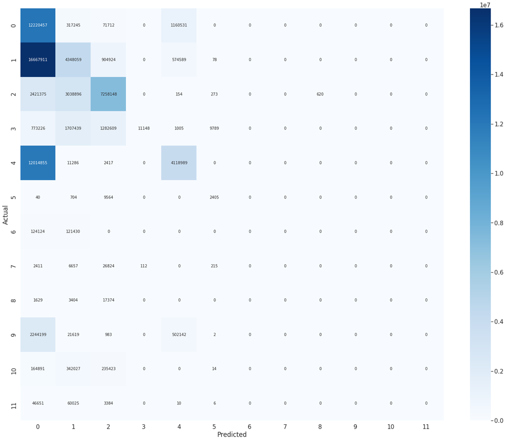

```python
y_true = labels1
y_pred = predictions1
data = confusion_matrix(y_true, y_pred,labels=range(1,13))
conm = pd.DataFrame(data)
conm.index.name = 'Actual'
conm.columns.name = 'Predicted'
plt.figure(figsize = (25,20))
sn.set(font_scale=1.4)#for label size
sn.heatmap(conm, cmap="Blues", annot=True,annot_kws={"size": 10},fmt='d')# font size
```

```python
def accuracy(label, confusion_matrix):
    col = confusion_matrix[:, label]

    return confusion_matrix[label, label] / (col.sum() + 1)


def recall(label, confusion_matrix):
    row = confusion_matrix[label, :]


    return confusion_matrix[label, label]/ (row.sum()+1)

def get_per_class_ious(label, confusion_matrix):


    intersection = confusion_matrix[label, label]
    union = (np.sum(confusion_matrix[label, :])
             + np.sum(confusion_matrix[:, label])
             - intersection
            )
    if union == 0:
        union = 1

    return  round(float(intersection) / union ,3)
```

```python
from sklearn.metrics import f1_score
```

```python
def f1score(label ,confusion_matrix):

    return  2 * (accuracy(label, confusion_matrix) * recall(label, confusion_matrix)) / (accuracy(label, confusion_matrix) + recall(label, confusion_matrix))
```

```python
# save to dataframe
import os
import pandas
accuracy1=[]
recall1=[]
iou1 =[]

for label  in range(12):
    accuracy1.append(accuracy(label, data).round(decimals=3))
    recall1.append(recall(label, data).round(decimals=3))
    iou1.append(get_per_class_ious(label, data))
```

```python
df = pd.DataFrame(list(zip(accuracy1, recall1,iou1,L1)),  columns =['accuracy', 'recall','iou','name'])
```

```python
2 * df['accuracy']*df['recall']/(df['accuracy']+df['recall'])
```

[output not shown]

```python
df[['iou']].mean(axis=0)
```

```
iou    0.101167
dtype: float64
```

```python
df[['accuracy']].mean(axis=0)
```

```
accuracy    0.272
dtype: float64
```

num iteration is low we just wanna know the performance of the network with the parameter changes considering the low amount of time we have

## training on 8/8/2021 block size 16

```python
predictions = pd.read_csv (r'/data/semantic3d_data/convpoint/examples/semantic3d/models/SegBig_8192_nocolorTrue_drop0.5_bs16_2021-08-07-22-58-48/8048_xyz_intensity_rgb.labels', delimiter=' ', header= None)
```

```python
predictions[0].unique()
```

```
array([ 4,  3,  2,  1,  5,  6,  7,  9, 10])
```

```python
labels1 = labels[0].to_numpy()
predictions1 = predictions[0].to_numpy()
```

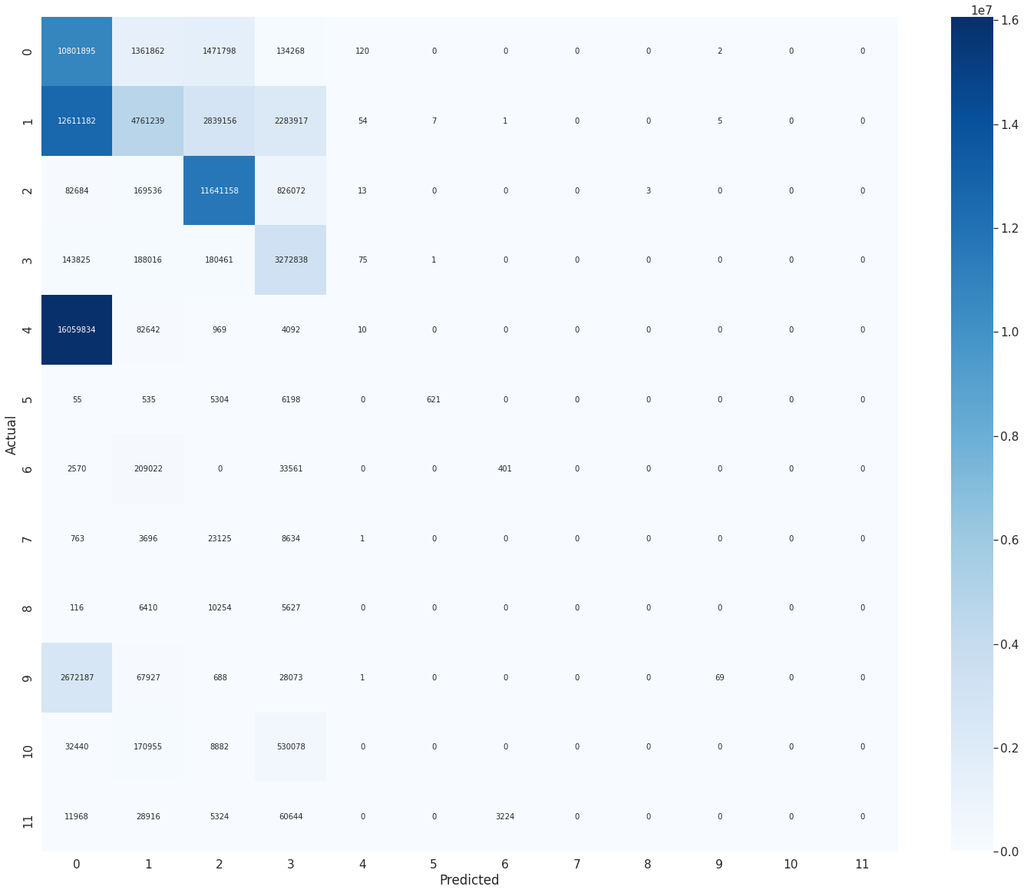

```python
y_true = labels1
y_pred = predictions1
data = confusion_matrix(y_true, y_pred,labels=range(1,13))
conm = pd.DataFrame(data)
conm.index.name = 'Actual'
conm.columns.name = 'Predicted'
plt.figure(figsize = (25,20))
sn.set(font_scale=1.4)#for label size
sn.heatmap(conm, cmap="Blues", annot=True,annot_kws={"size": 10},fmt='d')# font size
```

```python
# save to dataframe
import os
import pandas
accuracy1=[]
recall1=[]
iou1 =[]

for label  in range(12):
    accuracy1.append(accuracy(label, data).round(decimals=3))
    recall1.append(recall(label, data).round(decimals=3))
    iou1.append(get_per_class_ious(label, data))
```

```python
df = pd.DataFrame(list(zip(accuracy1, recall1,iou1,L1)),  columns =['accuracy', 'recall','iou','name'])
```

```python
df['iou']
```

```
0     0.238
1     0.192
2     0.674
3     0.425
4     0.000
5     0.049
6     0.002
7     0.000
8     0.000
9     0.000
10    0.000
11    0.000
Name: iou, dtype: float64
```

```python
df[['iou']].mean(axis=0)
```

```
iou    0.131667
dtype: float64
```

```python
df['accuracy']
```

```
0     0.255
1     0.675
2     0.719
3     0.455
4     0.036
5     0.986
6     0.111
7     0.000
8     0.000
9     0.896
10    0.000
11    0.000
Name: accuracy, dtype: float64
```

```python
df[['accuracy']].mean(axis=0)
```

```
accuracy    0.344417
dtype: float64
```

block size increasing improves iou

## training on 8/8/2021 block size 32

```python
predictions = pd.read_csv (r'/data/semantic3d_data/convpoint/examples/semantic3d/models/SegBig_8192_nocolorTrue_drop0.5_2021-08-08-16-08-32/8048_xyz_intensity_rgb.labels', delimiter=' ', header= None)
```

```python
predictions[0].unique()
```

```
array([ 3,  4,  2,  1,  9,  6,  5, 10,  7,  8, 12])
```

```python
labels1 = labels[0].to_numpy()
predictions1 = predictions[0].to_numpy()
```

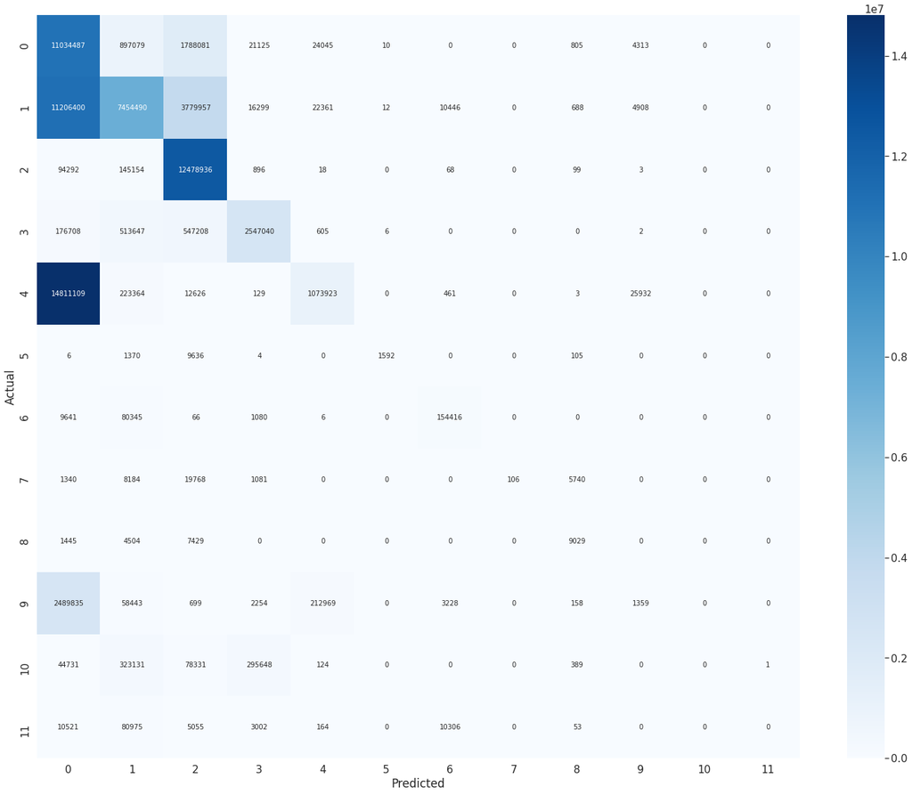

```python
y_true = labels1
y_pred = predictions1
data = confusion_matrix(y_true, y_pred,labels=range(1,13))
conm = pd.DataFrame(data)
conm.index.name = 'Actual'
conm.columns.name = 'Predicted'
plt.figure(figsize = (25,20))
sn.set(font_scale=1.4)#for label size
sn.heatmap(conm, cmap="Blues", annot=True,annot_kws={"size": 10},fmt='d')# font size
```

```python
# save to dataframe
import os
import pandas
accuracy1=[]
recall1=[]
iou1 =[]

for label  in range(12):
    accuracy1.append(accuracy(label, data).round(decimals=3))
    recall1.append(recall(label, data).round(decimals=3))
    iou1.append(get_per_class_ious(label, data))
```

```python
df = pd.DataFrame(list(zip(accuracy1, recall1,iou1,L1)),  columns =['accuracy', 'recall','iou','name'])
```

```python
df['iou']
```

```
0     0.259
1     0.300
2     0.658
3     0.617
4     0.065
5     0.125
6     0.572
7     0.003
8     0.297
9     0.000
10    0.000
11    0.000
Name: iou, dtype: float64
```

```python
df[['iou']].mean(axis=0)
```

```
iou    0.241333
dtype: float64
```

```python
df['accuracy']
```

```
0     0.277
1     0.761
2     0.666
3     0.882
4     0.805
5     0.982
6     0.863
7     0.991
8     0.529
9     0.037
10    0.000
11    0.000
Name: accuracy, dtype: float64
```

```python
df[['accuracy']].mean(axis=0)
```

```
accuracy    0.566083
dtype: float64
```

block size increasing improves iou

## training on 8/11/2021 block size 64

```python
predictions = pd.read_csv (r'/data/semantic3d_data/convpoint/examples/semantic3d/models/SegBig_8192_nocolorTrue_drop0.5_2021-08-09-16-53-15/8048_xyz_intensity_rgb.labels', delimiter=' ', header= None)
```

```python
predictions[0].unique()
```

```
array([ 3,  4,  2,  1,  9,  6,  5, 10,  7,  8, 12])
```

```python
labels1 = labels[0].to_numpy()
predictions1 = predictions[0].to_numpy()
```

```python
y_true = labels1
y_pred = predictions1
data = confusion_matrix(y_true, y_pred,labels=range(1,13))
conm = pd.DataFrame(data)
conm.index.name = 'Actual'
conm.columns.name = 'Predicted'
plt.figure(figsize = (25,20))
sn.set(font_scale=1.4)#for label size
#sn.heatmap(conm, cmap="Blues", annot=True,annot_kws={"size": 10},fmt='d')# font size
```

```python
# save to dataframe
import os
import pandas
accuracy1=[]
recall1=[]
iou1 =[]

for label  in range(12):
    accuracy1.append(accuracy(label, data).round(decimals=3))
    recall1.append(recall(label, data).round(decimals=3))
    iou1.append(get_per_class_ious(label, data))
```

```python
df = pd.DataFrame(list(zip(accuracy1, recall1,iou1,L1)),  columns =['accuracy', 'recall','iou','name'])
```

```python
df['iou']
```

```
0     0.219
1     0.311
2     0.709
3     0.693
4     0.491
5     0.015
6     0.514
7     0.199
8     0.266
9     0.107
10    0.000
11    0.010
Name: iou, dtype: float64
```

```python
df[['iou']].mean(axis=0)
```

```
iou    0.2945
dtype: float64
```

```python
df['accuracy']
```

```
0     0.328
1     0.658
2     0.723
3     0.849
4     0.612
5     0.667
6     0.722
7     0.781
8     0.411
9     0.169
10    0.000
11    0.095
Name: accuracy, dtype: float64
```

```python
df[['accuracy']].mean(axis=0)
```

```
accuracy    0.50125
dtype: float64
```

block size increasing improves iou but accuracy is dropping

## training on 8/11/2021 block size 100

```python
predictions = pd.read_csv (r'/data/semantic3d_data/convpoint/examples/semantic3d/models/SegBig_8192_nocolorTrue_drop0.5_2021-08-11-01-54-56/8048_xyz_intensity_rgb.labels', delimiter=' ', header= None)
```

```python
predictions[0].unique()
```

```
array([ 4,  3,  2,  1,  5,  9,  6, 10,  8, 12,  7])
```

```python
labels1 = labels[0].to_numpy()
predictions1 = predictions[0].to_numpy()
```

```python
y_true = labels1
y_pred = predictions1
data = confusion_matrix(y_true, y_pred,labels=range(1,13))
conm = pd.DataFrame(data)
conm.index.name = 'Actual'
conm.columns.name = 'Predicted'
plt.figure(figsize = (25,20))
sn.set(font_scale=1.4)#for label size
#sn.heatmap(conm, cmap="Blues", annot=True,annot_kws={"size": 10},fmt='d')# font size
```

```python
# save to dataframe
import os
import pandas
accuracy1=[]
recall1=[]
iou1 =[]

for label  in range(12):
    accuracy1.append(accuracy(label, data).round(decimals=3))
    recall1.append(recall(label, data).round(decimals=3))
    iou1.append(get_per_class_ious(label, data))
```

```python
df = pd.DataFrame(list(zip(accuracy1, recall1,iou1,L1)),  columns =['accuracy', 'recall','iou','name'])
```

```python
df['iou']
```

```
0     0.275
1     0.312
2     0.644
3     0.278
4     0.413
5     0.239
6     0.000
7     0.002
8     0.285
9     0.026
10    0.000
11    0.007
Name: iou, dtype: float64
```

```python
df[['iou']].mean(axis=0)
```

```
iou    0.20675
dtype: float64
```

```python
df['accuracy']
```

```
0     0.318
1     0.591
2     0.679
3     0.822
4     0.780
5     0.336
6     0.000
7     0.892
8     0.526
9     0.354
10    0.000
11    0.792
Name: accuracy, dtype: float64
```

```python
df[['accuracy']].mean(axis=0)
```

```
accuracy    0.5075
dtype: float64
```

## training on 8/12/2021 block size 50

```python
predictions = pd.read_csv (r'/data/semantic3d_data/convpoint/examples/semantic3d/models/SegBig_8192_nocolorTrue_drop0.5_bs50_2021-08-11-23-21-25/8048_xyz_intensity_rgb.labels', delimiter=' ', header= None)
```

```python
predictions[0].unique()
```

```
array([ 2,  3,  1,  4,  6,  5,  8,  9,  7, 10])
```

```python
labels1 = labels[0].to_numpy()
predictions1 = predictions[0].to_numpy()
```

```python
y_true = labels1
y_pred = predictions1
data = confusion_matrix(y_true, y_pred,labels=range(1,13))
conm = pd.DataFrame(data)
conm.index.name = 'Actual'
conm.columns.name = 'Predicted'
plt.figure(figsize = (25,20))
sn.set(font_scale=1.4)#for label size
#sn.heatmap(conm, cmap="Blues", annot=True,annot_kws={"size": 10},fmt='d')# font size
```

```python
# save to dataframe
import os
import pandas
accuracy1=[]
recall1=[]
iou1 =[]

for label  in range(12):
    accuracy1.append(accuracy(label, data).round(decimals=3))
    recall1.append(recall(label, data).round(decimals=3))
    iou1.append(get_per_class_ious(label, data))
```

```python
df = pd.DataFrame(list(zip(accuracy1, recall1,iou1,L1)),  columns =['accuracy', 'recall','iou','name'])
```

```python
df['iou']
```

```
0     0.264
1     0.307
2     0.697
3     0.384
4     0.311
5     0.277
6     0.032
7     0.172
8     0.335
9     0.021
10    0.000
11    0.000
Name: iou, dtype: float64
```

```python
df[['iou']].mean(axis=0)
```

```
iou    0.233333
dtype: float64
```

```python
df['accuracy']
```

```
0     0.296
1     0.636
2     0.720
3     0.906
4     0.798
5     0.857
6     0.956
7     0.892
8     0.660
9     0.076
10    0.000
11    0.000
Name: accuracy, dtype: float64
```

```python
df[['accuracy']].mean(axis=0)
```

```
accuracy    0.566417
dtype: float64
```

Based on the mean IOU the block size selected from now on is 64m

## training on 8/14/2021 with SGD optimizér and learning rate of 0.05

```python
predictions = pd.read_csv (r'/data/semantic3d_data/convpoint/examples/semantic3d/models/SegBig_8192_nocolorTrue_drop0.5_SGD_lr0.05_2021-08-14-00-51-47/8048_xyz_intensity_rgb.labels', delimiter=' ', header= None)
```

```python
predictions[0].unique()
```

```
array([ 1,  3,  2,  4,  6,  5,  9, 10])
```

```python
labels1 = labels[0].to_numpy()
predictions1 = predictions[0].to_numpy()
```

```python
y_true = labels1
y_pred = predictions1
data = confusion_matrix(y_true, y_pred,labels=range(1,13))
conm = pd.DataFrame(data)
conm.index.name = 'Actual'
conm.columns.name = 'Predicted'
plt.figure(figsize = (25,20))
sn.set(font_scale=1.4)#for label size
#sn.heatmap(conm, cmap="Blues", annot=True,annot_kws={"size": 10},fmt='d')# font size
```

```python
# save to dataframe
import os
import pandas
accuracy1=[]
recall1=[]
iou1 =[]

for label  in range(12):
    accuracy1.append(accuracy(label, data).round(decimals=3))
    recall1.append(recall(label, data).round(decimals=3))
    iou1.append(get_per_class_ious(label, data))
```

```python
df = pd.DataFrame(list(zip(accuracy1, recall1,iou1,L1)),  columns =['accuracy', 'recall','iou','name'])
```

```python
df['iou']
```

```
0     0.233
1     0.098
2     0.672
3     0.114
4     0.100
5     0.154
6     0.000
7     0.000
8     0.215
9     0.000
10    0.000
11    0.000
Name: iou, dtype: float64
```

```python
df[['iou']].mean(axis=0)
```

```
iou    0.132167
dtype: float64
```

```python
df['accuracy']
```

```
0     0.234
1     0.747
2     0.896
3     0.985
4     0.879
5     0.813
6     0.000
7     0.000
8     0.491
9     0.000
10    0.000
11    0.000
Name: accuracy, dtype: float64
```

```python
df[['accuracy']].mean(axis=0)
```

```
accuracy    0.420417
dtype: float64
```

SGD is not improving the results with a learning rate of 0.05

## training on 8/14/2021 with SGD optimizér and learning rate of 0.1

```python
predictions = pd.read_csv (r'/data/semantic3d_data/convpoint/examples/semantic3d/models/SegBig_8192_nocolorTrue_drop0.5_SGD_lr0.1_2021-08-14-21-52-10/8048_xyz_intensity_rgb.labels', delimiter=' ', header= None)
```

```python
s[0].unique()
```

```
array([0])
```

```python
labels1 = labels[0].to_numpy()
predictions1 = predictions[0].to_numpy()
```

```python
y_true = labels1
y_pred = predictions1
data = confusion_matrix(y_true, y_pred,labels=range(1,13))
conm = pd.DataFrame(data)
conm.index.name = 'Actual'
conm.columns.name = 'Predicted'
plt.figure(figsize = (25,20))
sn.set(font_scale=1.4)#for label size
#sn.heatmap(conm, cmap="Blues", annot=True,annot_kws={"size": 10},fmt='d')# font size
```

```python
# save to dataframe
import os
import pandas
accuracy1=[]
recall1=[]
iou1 =[]

for label  in range(12):
    accuracy1.append(accuracy(label, data).round(decimals=3))
    recall1.append(recall(label, data).round(decimals=3))
    iou1.append(get_per_class_ious(label, data))
```

```python
df = pd.DataFrame(list(zip(accuracy1, recall1,iou1,L1)),  columns =['accuracy', 'recall','iou','name'])
```

```python
df['iou']
```

```
0     0.189
1     0.000
2     0.000
3     0.000
4     0.000
5     0.000
6     0.000
7     0.000
8     0.000
9     0.000
10    0.000
11    0.000
Name: iou, dtype: float64
```

```python
df[['iou']].mean(axis=0)
```

```
iou    0.01575
dtype: float64
```

```python
df['accuracy']
```

```
0     0.189
1     0.000
2     0.000
3     0.000
4     0.000
5     0.000
6     0.000
7     0.000
8     0.000
9     0.000
10    0.000
11    0.000
Name: accuracy, dtype: float64
```

```python
df[['accuracy']].mean(axis=0)
```

```
accuracy    0.01575
dtype: float64
```

increasing the learning rate with SGD optimizer had made the model diverge hence the Adam optimizer will be kept

## training on 8/14/2021 with drouput of 0.25

```python
predictions = pd.read_csv (r'/data/semantic3d_data/convpoint/examples/semantic3d/models/SegBig_8192_nocolorTrue_drop0.25_2021-08-16-10-03-34/8048_xyz_intensity_rgb.labels', delimiter=' ', header= None)
```

```python
s[0].unique()
```

```
array([0])
```

```python
labels1 = labels[0].to_numpy()
predictions1 = predictions[0].to_numpy()
```

```python
y_true = labels1
y_pred = predictions1
data = confusion_matrix(y_true, y_pred,labels=range(1,13))
conm = pd.DataFrame(data)
conm.index.name = 'Actual'
conm.columns.name = 'Predicted'
plt.figure(figsize = (25,20))
sn.set(font_scale=1.4)#for label size
#sn.heatmap(conm, cmap="Blues", annot=True,annot_kws={"size": 10},fmt='d')# font size
```

```python
# save to dataframe
import os
import pandas
accuracy1=[]
recall1=[]
iou1 =[]

for label  in range(12):
    accuracy1.append(accuracy(label, data).round(decimals=3))
    recall1.append(recall(label, data).round(decimals=3))
    iou1.append(get_per_class_ious(label, data))
```

```python
df = pd.DataFrame(list(zip(accuracy1, recall1,iou1,L1)),  columns =['accuracy', 'recall','iou','name'])
```

```python
df['iou']
```

```
0     0.259
1     0.227
2     0.650
3     0.665
4     0.145
5     0.020
6     0.463
7     0.241
8     0.245
9     0.018
10    0.000
11    0.002
Name: iou, dtype: float64
```

```python
df[['iou']].mean(axis=0)
```

```
iou    0.244583
dtype: float64
```

```python
df['accuracy']
```

```
0     0.283
1     0.597
2     0.661
3     0.882
4     0.707
5     0.907
6     0.908
7     0.835
8     0.472
9     0.342
10    0.000
11    0.201
Name: accuracy, dtype: float64
```

```python
df[['accuracy']].mean(axis=0)
```

```
accuracy    0.56625
dtype: float64
```

```python
droupout decrease did improved the accuracy but not the mean IOU hence the default value will be maintained
```

# Build a deeper feed-forward network with an extra hidden layer layers

# MLP with 1 extra hidden layer similar to the output layer

this is how I changed the feed-forwards  
`self.l1 = nn.Linear(dim*n_centers, 2*n_centers)`  
`self.l2 = nn.Linear(2*n_centers, n_centers)`  
`self.l3 = nn.Linear(n_centers, n_centers)`  
`self.l4 = nn.Linear(n_centers, n_centers)`

Afterwards applying Relu function on the new hidden layer  
`dists = F.relu(self.l3(dists))`

```python
s[0].unique()
```

```
array([0])
```

```python
labels1 = labels[0].to_numpy()
predictions1 = predictions[0].to_numpy()
```

```python
y_true = labels1
y_pred = predictions1
data = confusion_matrix(y_true, y_pred,labels=range(1,13))
conm = pd.DataFrame(data)
conm.index.name = 'Actual'
conm.columns.name = 'Predicted'
plt.figure(figsize = (25,20))
sn.set(font_scale=1.4)#for label size
#sn.heatmap(conm, cmap="Blues", annot=True,annot_kws={"size": 10},fmt='d')# font size
```

```python
# save to dataframe
import os
import pandas
accuracy1=[]
recall1=[]
iou1 =[]

for label  in range(12):
    accuracy1.append(accuracy(label, data).round(decimals=3))
    recall1.append(recall(label, data).round(decimals=3))
    iou1.append(get_per_class_ious(label, data))
```

```python
df = pd.DataFrame(list(zip(accuracy1, recall1,iou1,L1)),  columns =['accuracy', 'recall','iou','name'])
```

```python
df['iou']
```

```
0     0.299
1     0.385
2     0.666
3     0.500
4     0.410
5     0.066
6     0.195
7     0.163
8     0.103
9     0.124
10    0.000
11    0.000
Name: iou, dtype: float64
```

```python
df[['iou']].mean(axis=0)
```

```
iou    0.242583
dtype: float64
```

```python
df['accuracy']
```

```
0     0.371
1     0.702
2     0.680
3     0.870
4     0.754
5     0.926
6     0.726
7     0.533
8     0.554
9     0.173
10    0.000
11    0.000
Name: accuracy, dtype: float64
```

```python
df[['accuracy']].mean(axis=0)
```

```
accuracy    0.524083
dtype: float64
```

```python
no improvement when adding 1 more hidden layer
```

# Build a deeper feed-forward network with an extra hidden layer layers

# MLP with 1 extra hidden layer and x 2 number of hidden nodes

This is how I changed the feed-forwards  
`self.l1 = nn.Linear(dim*n_centers, 4*n_centers)`  
`self.l2 = nn.Linear(4*n_centers, 2*n_centers)`  
`self.l3 = nn.Linear(2*n_centers, n_centers)`  
`self.l4 = nn.Linear(n_centers, n_centers)`

Apply 1 more relu Function on the extra hidden layer  
`dists = F.relu(self.l3(dists))`

```python
predictions = pd.read_csv (r'/data/semantic3d_data/convpoint/examples/semantic3d/models/SegBig_8192_nocolorTrue_drop0.5_2021-08-17-20-34-46/8048_xyz_intensity_rgb.labels', delimiter=' ', header= None)
```

```python
predictions[0].unique()
```

```
array([ 3,  2,  1,  5,  4, 12,  9,  6, 10, 11])
```

```python
labels1 = labels[0].to_numpy()
predictions1 = predictions[0].to_numpy()
```

```python
y_true = labels1
y_pred = predictions1
data = confusion_matrix(y_true, y_pred,labels=range(1,13))
conm = pd.DataFrame(data)
conm.index.name = 'Actual'
conm.columns.name = 'Predicted'
plt.figure(figsize = (25,20))
sn.set(font_scale=1.4)#for label size
#sn.heatmap(conm, cmap="Blues", annot=True,annot_kws={"size": 10},fmt='d')# font size
```

```python
# save to dataframe
import os
import pandas
accuracy1=[]
recall1=[]
iou1 =[]

for label  in range(12):
    accuracy1.append(accuracy(label, data).round(decimals=3))
    recall1.append(recall(label, data).round(decimals=3))
    iou1.append(get_per_class_ious(label, data))
```

```python
df = pd.DataFrame(list(zip(accuracy1, recall1,iou1,L1)),  columns =['accuracy', 'recall','iou','name'])
```

```python
df['iou']
```

```
0     0.245
1     0.277
2     0.676
3     0.435
4     0.216
5     0.272
6     0.000
7     0.000
8     0.070
9     0.000
10    0.000
11    0.002
Name: iou, dtype: float64
```

```python
df[['iou']].mean(axis=0)
```

```
iou    0.18275
dtype: float64
```

```python
df['accuracy']
```

```
0     0.274
1     0.613
2     0.710
3     0.741
4     0.658
5     0.307
6     0.000
7     0.000
8     0.101
9     0.004
10    0.000
11    0.023
Name: accuracy, dtype: float64
```

```python
df[['accuracy']].mean(axis=0)
```

```
accuracy    0.285917
dtype: float64
```

the number of layer is too many which lead to less performance.Hence and according to (@ARTICLE{1165576, author={Lippmann, R.}, journal={IEEE ASSP Magazine}, title={An introduction to computing with neural nets}, year={1987}, volume={4}, number={2}, pages={4-22}, doi={10.1109/MASSP.1987.1165576}}), 2 hidden layers are enough to perform a classification task fairly. Let us see wether or not an MLP with 1 hidden layer is enough to have comperable results with 2 hidden layers .

## training with 1 hidden layer in each discrete convolution

the code that make only 1 hidden layer is:  
`self.l1 = nn.Linear(dim*n_centers, n_centers)`  
`self.l4 = nn.Linear(n_centers, n_centers)`

```python
predictions = pd.read_csv (r'/data/semantic3d_data/convpoint/examples/semantic3d/models/SegBig_8192_nocolorTrue_drop0.5_2021-08-18-12-46-37/8048_xyz_intensity_rgb.labels', delimiter=' ', header= None)
```

```python
predictions[0].unique()
```

```
array([ 2,  4,  3,  1,  9, 10,  5,  6,  7,  8])
```

```python
labels1 = labels[0].to_numpy()
predictions1 = predictions[0].to_numpy()
```

```python
y_true = labels1
y_pred = predictions1
data = confusion_matrix(y_true, y_pred,labels=range(1,13))
conm = pd.DataFrame(data)
conm.index.name = 'Actual'
conm.columns.name = 'Predicted'
plt.figure(figsize = (25,20))
sn.set(font_scale=1.4)#for label size
#sn.heatmap(conm, cmap="Blues", annot=True,annot_kws={"size": 10},fmt='d')# font size
```

```python
# save to dataframe
import os
import pandas
accuracy1=[]
recall1=[]
iou1 =[]

for label  in range(12):
    accuracy1.append(accuracy(label, data).round(decimals=3))
    recall1.append(recall(label, data).round(decimals=3))
    iou1.append(get_per_class_ious(label, data))
```

```python
df = pd.DataFrame(list(zip(accuracy1, recall1,iou1,L1)),  columns =['accuracy', 'recall','iou','name'])
```

```python
df['iou']
```

```
0     0.278
1     0.387
2     0.659
3     0.327
4     0.228
5     0.130
6     0.008
7     0.106
8     0.262
9     0.014
10    0.000
11    0.000
Name: iou, dtype: float64
```

```python
df[['iou']].mean(axis=0)
```

```
iou    0.199917
dtype: float64
```

```python
df['accuracy']
```

```
0     0.315
1     0.668
2     0.668
3     0.839
4     0.814
5     0.747
6     0.235
7     0.958
8     0.566
9     0.063
10    0.000
11    0.000
Name: accuracy, dtype: float64
```

```python
df[['accuracy']].mean(axis=0)
```

```
accuracy    0.489417
dtype: float64
```

## training with a voxel size of 0.2m

No improvement.

## training with a voxel size of 0.05m

The training IOU is better hence we consider this voxel size for data preparation

## increase the batch size without increasing the training time (number of iterations)

We simply change in the training python rep "semantic3d_seg.py" line 300  
`iteration_number=args.batch_size*args.iter`  
with  
`iteration_number=args.iter`

## Training with 6 conv 6 deconv layer instead of 7 conv and 6 deconv layers.

Removing the last conv layer is done through this modification in the network .py file : we remove this 2 lines of code

`x6, pts6 = self.cv6(x5, pts5, 4, 8)`  
`x6 = self.relu(apply_bn(x6, self.bn6))`  
and keep the skip connections configuation the same.  
In the xd5 deconv layer we change in the first line pts6 to pts 5.

```python
predictions = pd.read_csv (r'/data/semantic3d_data/convpoint/examples/semantic3d/models/SegBig_8192_nocolorTrue_drop0.5_2021-08-29-14-34-11/8048_xyz_intensity_rgb.labels', delimiter=' ', header= None)
```

```python
predictions[0].unique()
```

```
array([ 4,  2,  3,  1,  9,  5, 10,  6,  7,  8])
```

```python
labels1 = labels[0].to_numpy()
predictions1 = predictions[0].to_numpy()
```

```python
y_true = labels1
y_pred = predictions1
data = confusion_matrix(y_true, y_pred,labels=range(1,13))
conm = pd.DataFrame(data)
conm.index.name = 'Actual'
conm.columns.name = 'Predicted'
plt.figure(figsize = (25,20))
sn.set(font_scale=1.4)#for label size
#sn.heatmap(conm, cmap="Blues", annot=True,annot_kws={"size": 10},fmt='d')# font size
```

```python
# save to dataframe
import os
import pandas
accuracy1=[]
recall1=[]
iou1 =[]

for label  in range(12):
    accuracy1.append(accuracy(label, data).round(decimals=3))
    recall1.append(recall(label, data).round(decimals=3))
    iou1.append(get_per_class_ious(label, data))
```

```python
df = pd.DataFrame(list(zip(accuracy1, recall1,iou1,L1)),  columns =['accuracy', 'recall','iou','name'])
```

```python
df['iou']
```

```
0     0.174
1     0.348
2     0.730
3     0.583
4     0.374
5     0.297
6     0.029
7     0.102
8     0.274
9     0.036
10    0.000
11    0.000
Name: iou, dtype: float64
```

```python
df[['iou']].mean(axis=0)
```

```
iou    0.245583
dtype: float64
```

```python
df['accuracy']
```

```
0     0.228
1     0.664
2     0.770
3     0.869
4     0.578
5     0.805
6     0.539
7     0.679
8     0.427
9     0.337
10    0.000
11    0.000
Name: accuracy, dtype: float64
```

```python
df[['accuracy']].mean(axis=0)
```

```
accuracy    0.491333
dtype: float64
```

```python
predictions = pd.read_csv (r'/data/semantic3d_data/convpoint/examples/semantic3d/models/sem8_8192_fusion_2021-09-02-03-58-00/8050_xyz_intensity_rgb.labels', delimiter=' ', header= None)
```

```python
labels = pd.read_csv (r'/data/semantic3d_data/convpoint/examples/semantic3d/data/LATER/8050_xyz_intensity_rgb.labels', delimiter=' ', header= None)
```

```python
labels[0]
```

```
0           11
1           11
2           11
3           11
4           11
            ..
75555271     0
75555272     0
75555273     0
75555274     0
75555275     0
Name: 0, Length: 75555276, dtype: int64
```

```python
labels1 = labels[0].to_numpy()
predictions1 = predictions[0].to_numpy()
```

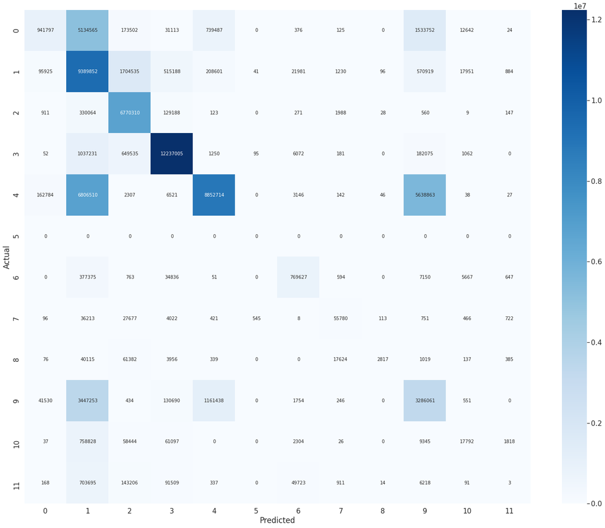

```python
y_true = labels1
y_pred = predictions1
data = confusion_matrix(y_true, y_pred,labels=range(1,13))
conm = pd.DataFrame(data)
conm.index.name = 'Actual'
conm.columns.name = 'Predicted'
plt.figure(figsize = (25,20))
sn.set(font_scale=1.4)#for label size
sn.heatmap(conm, cmap="Blues", annot=True,annot_kws={"size": 10},fmt='d')# font size
```

```python
df_cm = conm.copy()
df_cm.columns = [ 'natural_ground','low_vegetation','high_vegetation','buildings','road','wire_structure','vehicules','lamps','street_signs','manmade_terrain','barrier','remaining_hardsapes']
df_cm["sum"] = df_cm.sum(axis =1)
df_cm.loc[:,:] = df_cm.loc[:,:].div(df_cm["sum"], axis=0)
df_cm
```

| Actual | natural_ground | low_vegetation | high_vegetation | buildings | road | wire_structure | vehicules | lamps | street_signs | manmade_terrain | barrier | remaining_hardsapes | sum |
| --- | --- | --- | --- | --- | --- | --- | --- | --- | --- | --- | --- | --- | --- |
| 0 | 0.109928 | 0.599315 | 0.020251 | 0.003632 | 0.086314 | 0.000000 | 0.000044 | 0.000015 | 0.000000 | 0.179022 | 0.001476 | 0.000003 | 1.0 |
| 1 | 0.007657 | 0.749557 | 0.136067 | 0.041126 | 0.016652 | 0.000003 | 0.001755 | 0.000098 | 0.000008 | 0.045574 | 0.001433 | 0.000071 | 1.0 |
| 2 | 0.000126 | 0.045629 | 0.935953 | 0.017859 | 0.000017 | 0.000000 | 0.000037 | 0.000275 | 0.000004 | 0.000077 | 0.000001 | 0.000020 | 1.0 |
| 3 | 0.000004 | 0.073487 | 0.046019 | 0.866978 | 0.000089 | 0.000007 | 0.000430 | 0.000013 | 0.000000 | 0.012900 | 0.000075 | 0.000000 | 1.0 |
| 4 | 0.007581 | 0.316978 | 0.000107 | 0.000304 | 0.412270 | 0.000000 | 0.000147 | 0.000007 | 0.000002 | 0.262601 | 0.000002 | 0.000001 | 1.0 |
| 5 | NaN | NaN | NaN | NaN | NaN | NaN | NaN | NaN | NaN | NaN | NaN | NaN | NaN |
| 6 | 0.000000 | 0.315344 | 0.000638 | 0.029110 | 0.000043 | 0.000000 | 0.643119 | 0.000496 | 0.000000 | 0.005975 | 0.004735 | 0.000541 | 1.0 |
| 7 | 0.000757 | 0.285560 | 0.218249 | 0.031716 | 0.003320 | 0.004298 | 0.000063 | 0.439857 | 0.000891 | 0.005922 | 0.003675 | 0.005693 | 1.0 |
| 8 | 0.000594 | 0.313766 | 0.480110 | 0.030943 | 0.002652 | 0.000000 | 0.000000 | 0.137849 | 0.022034 | 0.007970 | 0.001072 | 0.003011 | 1.0 |
| 9 | 0.005146 | 0.427171 | 0.000054 | 0.016195 | 0.143921 | 0.000000 | 0.000217 | 0.000030 | 0.000000 | 0.407197 | 0.000068 | 0.000000 | 1.0 |
| 10 | 0.000041 | 0.834160 | 0.064246 | 0.067162 | 0.000000 | 0.000000 | 0.002533 | 0.000029 | 0.000000 | 0.010273 | 0.019558 | 0.001998 | 1.0 |
| 11 | 0.000169 | 0.706610 | 0.143799 | 0.091888 | 0.000338 | 0.000000 | 0.049929 | 0.000915 | 0.000014 | 0.006244 | 0.000091 | 0.000003 | 1.0 |

```python
df_cm = df_cm.round(decimals=3)
df_cm = df_cm.fillna(0)
df_cm.drop("sum", axis = 1, inplace = True)
```

[output not shown]

```python
df_cm1 = df_cm.set_axis([ 'natural_ground','low_vegetation','high_vegetation','buildings','road','wire_structure','vehicules','lamps','street_signs','manmade_terrain','barrier','remaining_hardsapes'], axis=0)
```

```python
df_cm.iloc[:, 0]
```

```
Actual
0     0.110
1     0.008
2     0.000
3     0.000
4     0.008
5     0.000
6     0.000
7     0.001
8     0.001
9     0.005
10    0.000
11    0.000
Name: natural_ground, dtype: float64
```

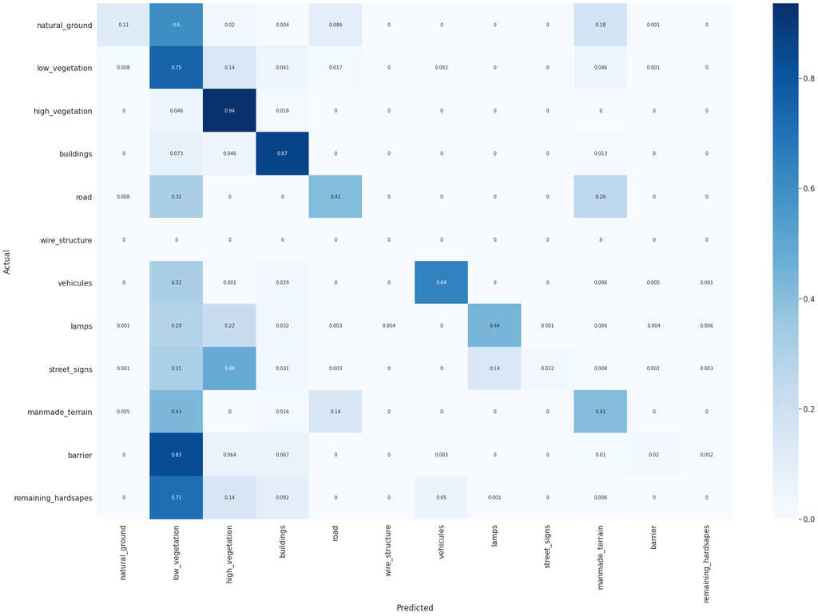

```python
df_cm1.index.name = 'Actual'
df_cm1.columns.name = 'Predicted'
plt.figure(figsize = (30,20))
sn.set(font_scale=1.4)#for label size
sn.heatmap(df_cm1, cmap="Blues", annot=True,annot_kws={"size": 10})# font size
```

```python
# save to dataframe
import os
import pandas
accuracy1=[]
recall1=[]
iou1 =[]

for label  in range(12):
    accuracy1.append(accuracy(label, data).round(decimals=3))
    recall1.append(recall(label, data).round(decimals=3))
    iou1.append(get_per_class_ious(label, data))
```

```python
df = pd.DataFrame(list(zip(accuracy1, recall1,iou1,L1)),  columns =['accuracy', 'recall','iou','name'])
```

```python
df['iou']
```

```
0     0.106
1     0.301
2     0.673
3     0.809
4     0.375
5     0.000
6     0.600
7     0.372
8     0.022
9     0.205
10    0.019
11    0.000
Name: iou, dtype: float64
```

```python
df[['iou']].mean(axis=0)
```

```
iou    0.290167
dtype: float64
```

```python
df['accuracy']
```

```
0     0.757
1     0.335
2     0.706
3     0.924
4     0.807
5     0.000
6     0.900
7     0.707
8     0.904
9     0.292
10    0.315
11    0.001
Name: accuracy, dtype: float64
```

```python
df[['accuracy']].mean(axis=0)
```

```
accuracy    0.554
dtype: float64
```

The results with the fusion model is relatevely the same with the no color model.